# MDA2025-U9-Losungen

```python
import numpy as np
import matplotlib.pyplot as plt
import matplotlib.cm as cm

import warnings
warnings.filterwarnings(action='ignore')
```

### Doppelintegrale

1. Berechne folgende Doppelintegrale: $\int_{x=0}^{1} \int_{y=0}^{1-x} (2xy - x^2 - y^2) \mathrm{d}y\mathrm{d}x$
2. Gegeben ist: $\int_{x=0}^{1} \int_{y=0}^{x} (x^2 + y^2) \mathrm{d}y\mathrm{d}x$  
   Können wir die Reihenfolge der Integration vertauschen?

Wenn ja, wie verändern sich die Integrationsgrenzen?  
Berechnen Sie beide Integrale und überzeugen Sie sich, dass sie gleich sind.

3. Welche Fläche schliessen die Kurven $y_1(x) = -x(x-3)$ und $y_2(x) = -2x$ ein?  
   Wo befindet sich der Flächenschwerpunkt?
4. Berechne den Schwerpunkt der Fläche, die durch die Kardioide $r(\varphi) = 1 + \cos(\varphi)$,

den Mittelpunktskreis mit $r = 2$ und den beiden Strahlen $\varphi = 0$ und $\varphi = \pi$ berandet wird.

5. Berechne folgende Doppelintegrale: $\dfrac{2}{3\pi}\int_{\varphi=0}^{2\pi} \int_{r=0}^{1+\cos(\varphi)} r^2 \cos(\varphi) \mathrm{d}r\mathrm{d}\varphi$

#### Lösungen

*1)*

$\int_{y=0}^{1-x} (2xy - x^2 - y^2) \mathrm{d}y = \left[xy^2 - x^2y - \dfrac{y^3}{3}\right]_0^{1-x} = x(1-x)^2 - x^2(1-x) - \dfrac{(1-x)^3}{3} = 2x - 4x^2 - \dfrac{1}{3} + \dfrac{7x^3}{3}$

$\int_{x=0}^{1} \left(2x - 4x^2 - \dfrac{1}{3} + \dfrac{7x^3}{3}\right) \mathrm{d}x = \left[x^2 - \dfrac{4x^3}{3} - \dfrac{x}{3} + \dfrac{7x^4}{12} \right]_0^1 =-\dfrac{1}{12}$

*2)*

Wir integrieren über den Bereich, in dem x zwischen 0 und 1 liegt und y zwischen den Geraden y = 0 und y = x. Dies beschreibt ein Dreieck. Man kann den Bereich auch so beschreiben, dass y zwischen 0 und 1 liegt und x zwischen der Geraden x = y und x = 1: $\int_{x=0}^{1} \int_{y=0}^{x} (x^2 + y^2) \mathrm{d}y\mathrm{d}x = \int_{y=0}^{1} \int_{x=y}^{1} (x^2 + y^2) \mathrm{d}x\mathrm{d}y$

*2a)* $\int_{x=0}^{1} \int_{y=0}^{x} (x^2 + y^2) \mathrm{d}y\mathrm{d}x =\int_{x=0}^{1} \left[x^2y + \frac{y^3}{3}\right]_0^x \mathrm{d}x =\int_{x=0}^{1} \frac43 x^3 \mathrm{d}x = \left[ \frac{x^4}{3} \right]_0^1 = \frac13$

*2b)* $\int_{y=0}^{1} \int_{x=y}^{1} (x^2 + y^2) \mathrm{d}x\mathrm{d}y =\int_{y=0}^{1} \left[ \frac13x^3+y^2x \right]_y^1 \mathrm{d}y =\int_{y=0}^{1} (\frac13+y^2-\frac13y^3-y^3 )\mathrm{d}y$  
$\;\;\;\;\;=\left[\frac13y+\frac13y^3-\frac13y^4 \right]_0^1 = \frac13$

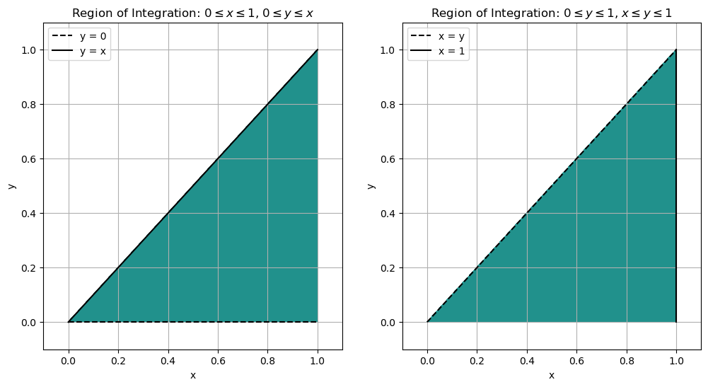

```python
x = np.linspace(0, 1, 300)
y = np.linspace(0, 1, 300)
X, Y = np.meshgrid(x, y)

region = Y <= X

fig = plt.figure(figsize=(12,6))

fig.add_subplot(121)
plt.contourf(X, Y, region, levels=[0.5, 1])
# boundary lines
plt.plot([0, 1], [0, 0 ], 'k--', label='y = 0')
plt.plot([0, 1], [0, 1], 'k-', label='y = x')
# Formatting
plt.xlabel('x')
plt.ylabel('y')
plt.title('Region of Integration: $0 \\leq x \\leq 1$, $0 \\leq y \\leq x$')
plt.legend()
plt.grid(True)
plt.xlim(-0.1, 1.1)
plt.ylim(-0.1, 1.1)

fig.add_subplot(122)
plt.contourf(X, Y, region, levels=[0.5, 1])
# boundary lines
plt.plot([0, 1], [0, 1], 'k--', label='x = y')
plt.plot([1, 1], [0, 1], 'k-', label='x = 1')
# Formatting
plt.xlabel('x')
plt.ylabel('y')
plt.title('Region of Integration: $0 \\leq y \\leq 1$, $x \\leq y \\leq 1$')
plt.legend()
plt.grid(True)
plt.xlim(-0.1, 1.1)
plt.ylim(-0.1, 1.1)

plt.show()
```

*3)*

Vorgehensweise:

- Bestimmung der Schnittpunkte
- Aufstellen des Doppelintegrals
- Lösen des Integrals

Schnittpunkte: $-x(x-3) = -2x, \; x_1 = 0, \; -x+3 = -2 \rightarrow x_2 = 5, \; y_1 = 0, \; y_2 = -10$

Integral: $\int_{x=0}^{5} \int_{y=-2x}^{-x(x-3)} \mathrm{d}y\mathrm{d}x = \dfrac{125}{6}$

Flächenschwerpunkt:

$x_s = \dfrac{1}{A}\iint_{(A)} x \mathrm{d}A = \dfrac{6}{125}\int_{x=0}^{5} \int_{y=-2x}^{-x(x-3)} x \mathrm{d}y\mathrm{d}x = \dfrac{5}{2}$

$y_s = \dfrac{1}{A}\iint_{(A)} y \mathrm{d}A = \dfrac{6}{125}\int_{x=0}^{5} \int_{y=-2x}^{-x(x-3)} y \mathrm{d}y\mathrm{d}x = -\dfrac{5}{2}$

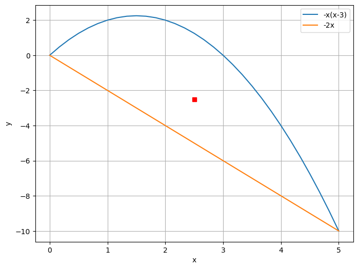

```python
x = np.linspace(0,5,31)
y1 = -x*(x-3)
y2 = -2*x

fig = plt.figure(figsize=(8,6))
ax = fig.add_subplot(111)
ax.plot(x,y1,label = '-x(x-3)')
ax.plot(x,y2,label = '-2x')
ax.plot(5/2,-5/2, marker='s', color='red')
ax.set_xlabel('x')
ax.set_ylabel('y')
ax.legend()
ax.grid()
plt.show()
```

*4)*

- Bestimmung der Integrationsgrenzen: $0 \le \varphi \le \pi, \; 1+\cos(\phi) \le r\le 2$
- Aufstellen des Integrals: $\int_{\varphi=0}^{\pi} \int_{r=1+\cos(\varphi)}^{2}r \mathrm{d}r\mathrm{d}\varphi = \dfrac{5}{4}\pi$
- Schwerpunkt:

$x_s = \dfrac{4}{5 \pi}\int_{\varphi=0}^{\pi} \int_{r=1+\cos(\varphi)}^{2} r \cos(\varphi) r \mathrm{d}r\mathrm{d}\varphi = -0.5$

$y_s = \dfrac{4}{5 \pi}\int_{\varphi=0}^{\pi} \int_{r=1+\cos(\varphi)}^{2} r \sin(\varphi) r \mathrm{d}r\mathrm{d}\varphi = \dfrac{16}{5 \pi}$

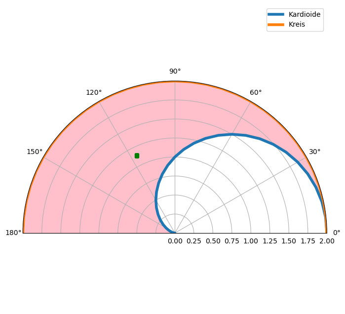

```
r_s: 1.1347
phi_s: 2.0271
```

```python
phi = np.linspace(0,2*np.pi,61)
r1 = 1 + np.cos(phi)
xs = -0.5
ys = 16/5/np.pi
fig = plt.figure(figsize=(8,8))
ax = fig.add_subplot(111, projection='polar')
ax.plot(phi,r1, label='Kardioide', linewidth=4)
ax.plot(phi, 2*np.ones_like(phi), label='Kreis', linewidth=4)
ax.plot(np.arctan2(ys,xs), np.sqrt(xs**2 + ys**2),'s', color='green')
ax.fill_between(phi, 2*np.ones_like(phi), r1, color='pink' )
ax.set_xlim([0,np.pi])
ax.set_ylim([0,2])
ax.legend()
plt.show()
print('r_s: {0:.4f}'.format(np.sqrt(xs**2 + ys**2)))
print('phi_s: {0:.4f}'.format(np.arctan2(ys,xs)))
```